# Presentation - Group 9

Analyze and offer solutions to improve marketing campaigns

2022-12-11

# Content 1. Introduce

## Introducing team members

- *Le Hoang Khang - 20133050*
- *Nguyen Thanh Hung - 20133045*
- *Phan Quoc Luu - 20133065*

## Introduction to the topic of data sets

- Topic: Let’s say you’re a marketing analyst and you’ve been told by your manager that recent marketing campaigns aren’t performing as expected. You need to analyze this data set to recommend solutions for your company according to the data set
- Link data: https://www.kaggle.com/code/jennifercrockett/marketing-analytics-eda-task-final/data

# Content 2.Data

- Information about which columns to use: 2240 obs. of 28 variables:
- ID: Customer’s unique identifier
- Year_Birth: Customer’s birth year
- Education: Customer’s education level
- Marital_Status: Customer’s marital status
- Income: Customer’s yearly household income
- Kidhome: Number of children in customer’s household
- Teenhome: Number of teenagers in customer’s household
- Dt_Customer: Date of customer’s enrollment with the company
- Recency: Number of days since customer’s last purchase
- Complain: 1 if the customer complained in the last 2 years, 0 otherwise
- MntWines: Amount spent on wine in last 2 years
- MntFruits: Amount spent on fruits in last 2 years
- MntMeatProducts: Amount spent on meat in last 2 years
- MntFishProducts: Amount spent on fish in last 2 years
- MntSweetProducts: Amount spent on sweets in last 2 years
- MntGoldProds: Amount spent on gold in last 2 years
- NumDealsPurchases: Number of purchases made with a discount
- AcceptedCmp1: 1 if customer accepted the offer in the 1st campaign, 0 otherwise
- AcceptedCmp2: 1 if customer accepted the offer in the 2nd campaign, 0 otherwise
- AcceptedCmp3: 1 if customer accepted the offer in the 3rd campaign, 0 otherwise
- AcceptedCmp4: 1 if customer accepted the offer in the 4th campaign, 0 otherwise
- AcceptedCmp5: 1 if customer accepted the offer in the 5th campaign, 0 otherwise
- Response: 1 if customer accepted the offer in the last campaign, 0 otherwise
- Country: Customer’s address
- NumWebPurchases: Number of purchases made through the company’s website
- NumCatalogPurchases: Number of purchases made using a catalogue
- NumStorePurchases: Number of purchases made directly in stores
- NumWebVistisMonth: Number of visits to company’s website in the last month

# Content 3. Data analysis plan

- The outcome (Y) and explanatory (X) variables that the team will use to answer the question:
  - Explanatory variable (X): Education, Marital_Status, Income, Year_Birth, Num…
  - Vriable outcome AcceptedCmp…, Response, Mnt…
- **Analysis goal**
  - **Data cleaning**
    - Eliminate nulls and outliers
    - Convert data columns to required form
    - Create some columns needed for analysis
  - **Statistical analysis:**
    - Is there a relationship between the region and the acceptance of a campaign (latest campaign)?
    - Is there a relationship between those with or without children and the acceptance of the most successful campaigns ?
  - **In-depth analytics using Machine Learning:**
    - Predict total customer spending based on personal income, number of purchases by methods, … (Algorithm Linear Regression )
    - Predict campaign acceptability of customers based on purchases, income, marital status, number of children in the family….. (Algorithm Logistic Regression)
  - **Data visualization**
    - Acceptance rate of marketing campaigns by region?
    - Which sales method is the least effective?
    - Which products account for the most revenue?
    - The most successful and the worst campaign?
  - **Conclusion**
    - Make comments and measures to improve the campaign

# Content 4. Accomplish goals

## 4.1. Data cleaning

- Marital status is divided into two large groups: single (alone, divorced, single, widow) and couple (married, together).
- Create a MntSpent column from MntFishProducts, MntMeatProducts, MntFruits, MntSweetProducts, MntWines, MntGoldProds columns.
- Create column NumPurchases including columns NumCatalog Purchases, NumStorePurchases, NumWebPurchases.
- The TotalAccepted column includes AcceptedCmp1, AcceptedCmp2, AcceptedCmp3, AcceptedCmp4, AcceptedCmp5.
- The child column is the column that categorizes customers with or without children.
- Remove outliers, null values, unnecessary columns.

## 4.2. Statistical analysis

### 4.2.1 Question number 1

- Is there a relationship between customers in each region and acceptance of a campaign (latest campaign)?
  - The group’s hypothesis

  ```
  -    Ho: There is no relationship between customers in each region with the acceptance of 1 campaign

  -    Ha: There is a relationship between customers in each region with the acceptance of 1 campaign
  ```

- Count of accept or disapproval by country

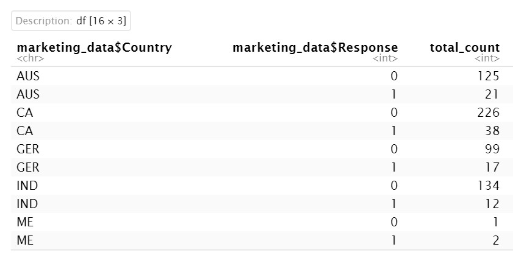

.

- Create a matrix with the number of rows being the number of countries, and the column consisting of 2 columns (the first column is the number of people who accept the campaign, the second column is the number of people who do not accept the campaign).
- Use chi-squared test to test the above hypothesis.

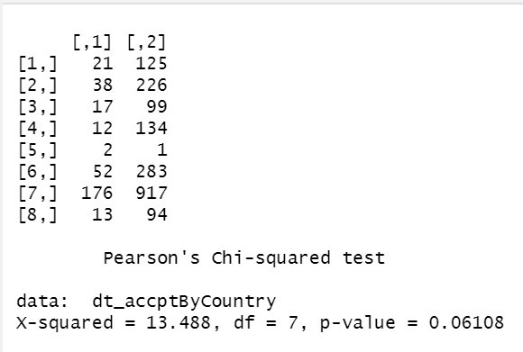

.

#### Comment

- With p-value = 0.06108 not less than 0.05, we cannot reject hypothesis Ho (reject Ha). We cannot conclude that there is a relationship between customers in each region and campaign adoption (2 completely independent variables).

### 4.2.2 Question number 2

- Is there a relationship between those with or without children and campaign acceptance (most successful) ?
  - The group’s hypothesis:
    - Ho: There is no relationship between those with or without children and campaign acceptance
    - Ha: Is there a relationship between people with or without children and campaign acceptance
- Count the accept or disapproval by people with or without children

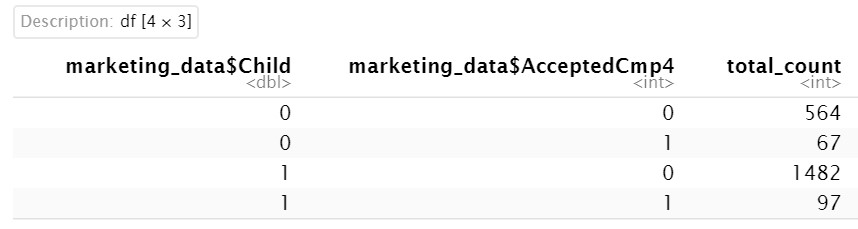

- Create a matrix with the number of rows being the number of people with or without children, and a column of 2 columns (the first column is the number of people who accept the campaign, the second column is the number of people who do not accept the campaign).
- Use chi-squared test to test the above hypothesis

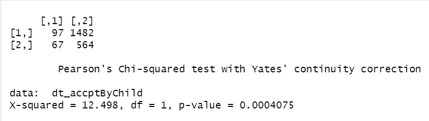

.

#### Comment

# 4.2.3 Predict total customer spending based on personal income, number of purchases by methods, … (**Algorithm Linear Regression**)

- Divide the model into 2 parts (70% train, 30% test)

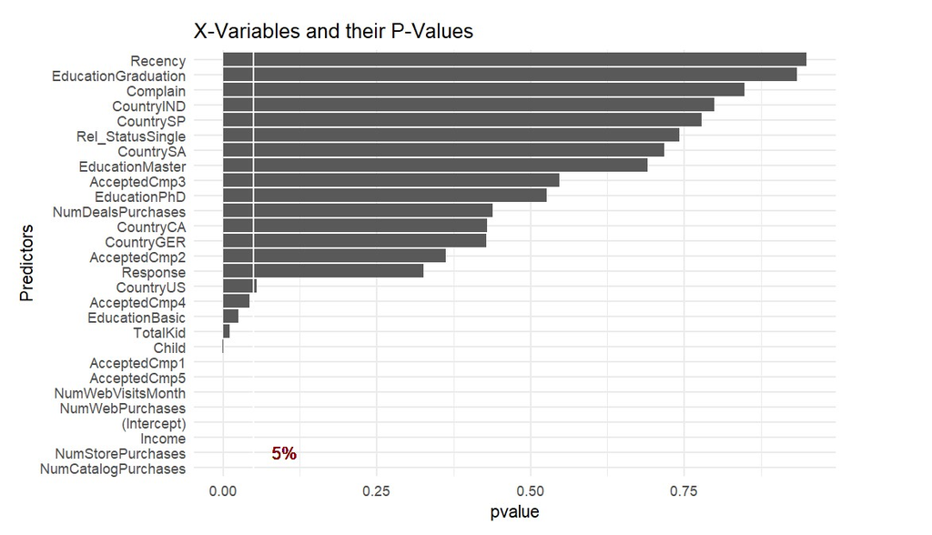

- Train the model after finding influential values

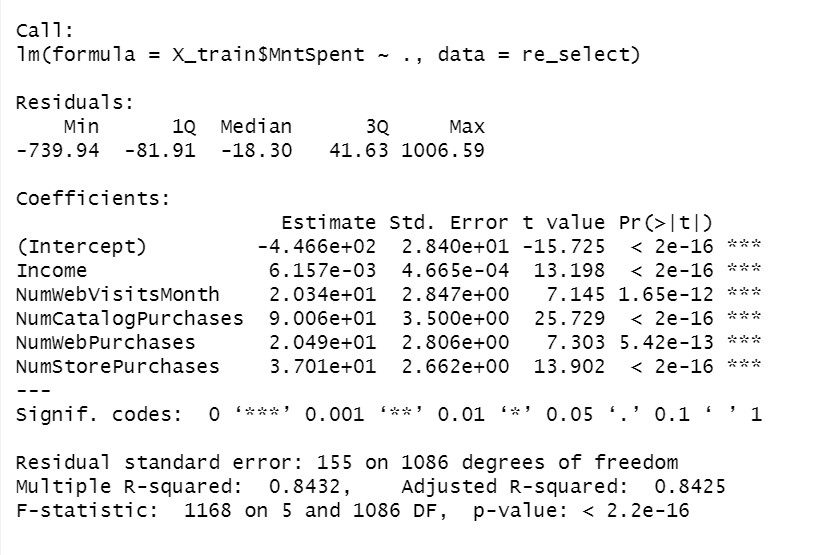

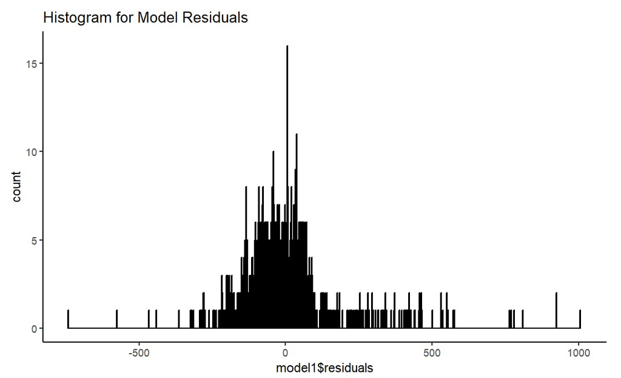

- Visualize some variables that affect the model

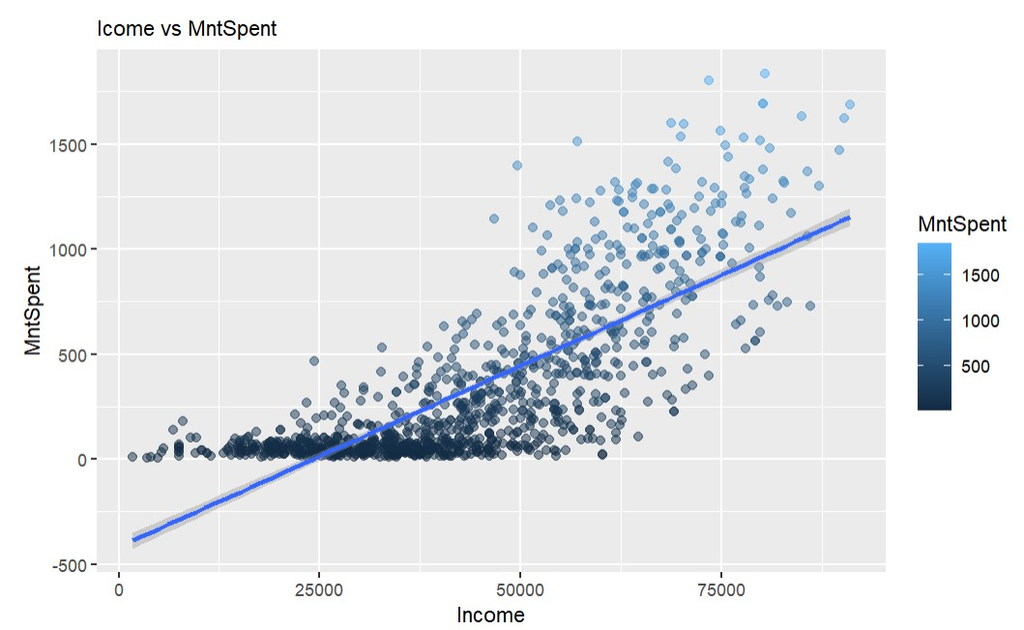

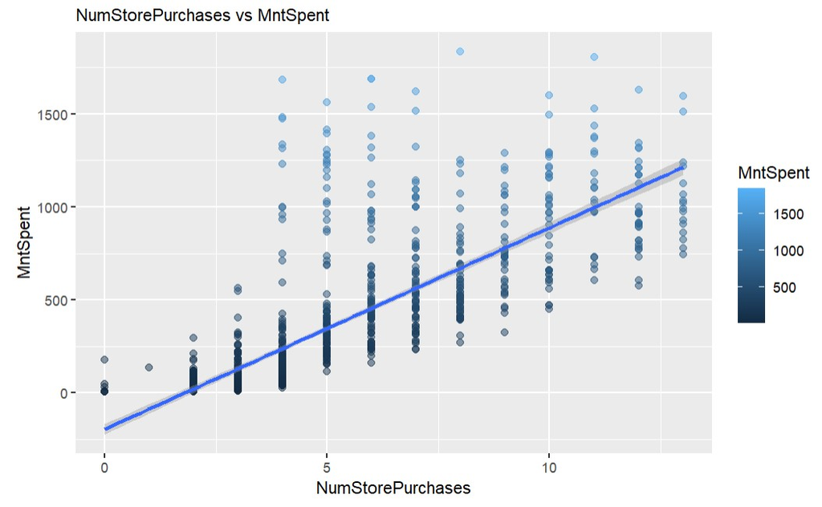

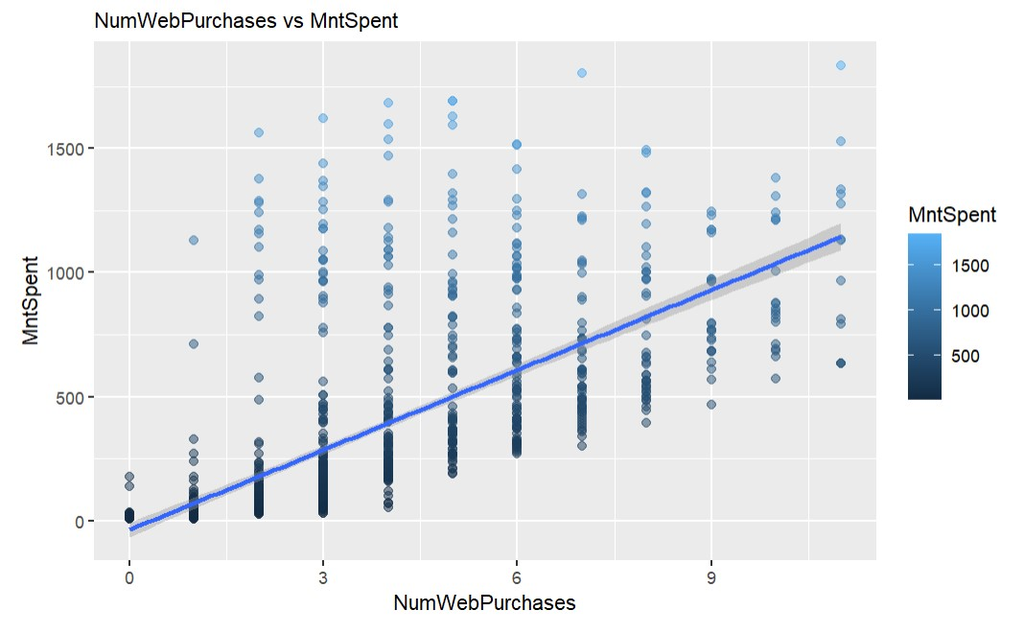

- Compare actual value and predicted value

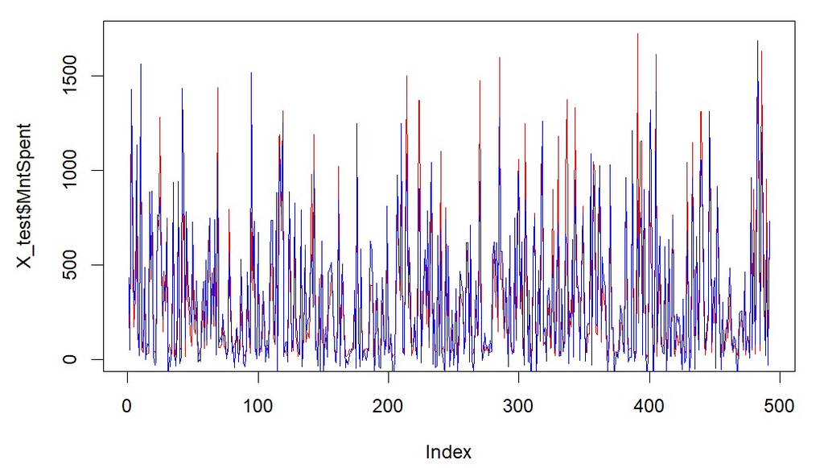

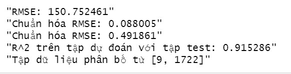

- The predictive model on the test set explains 91% of the variation of the dependent variables. This level of explanation is said to be quite good

# Predict campaign acceptability of customers based on purchases, income, marital status, number of children in the family…..(**Algorithm Logistic Regression**)

- Divide the model into 2 parts (70% train, 30% test)

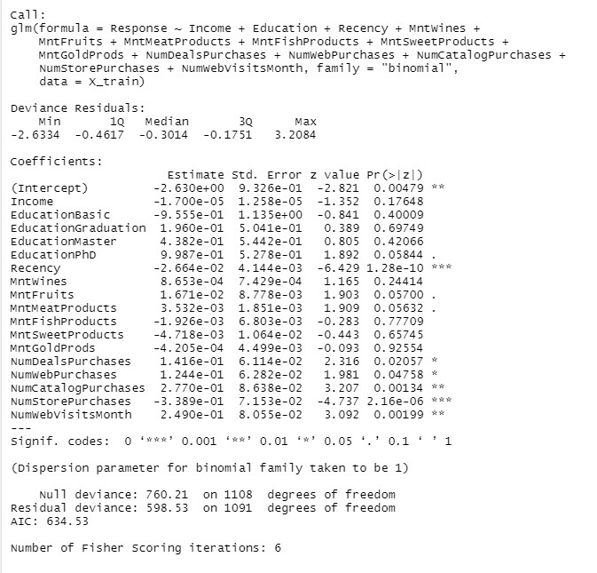

- 87% predictive model

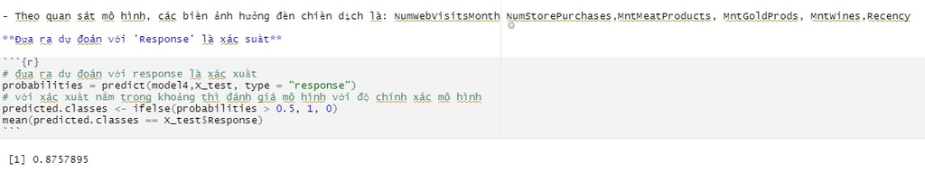

.

#### Comment

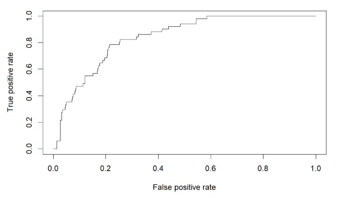

.

- The AUC curve indicator shows the model predictability with a success rate of 83%, showing that the model predicts quite well in terms of true negatives and true positives.

# 4.3. Data visualization

## 4.3.1 Acceptance rate of marketing campaigns by region ?

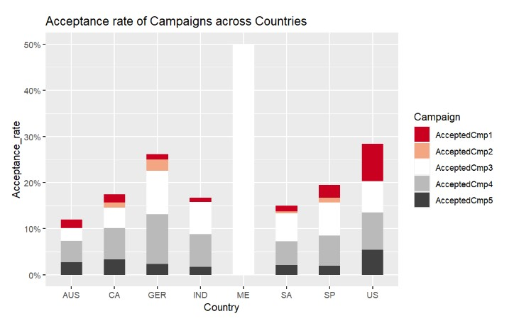

.